# The pgainsim users guide

Nora Scherer, Pascal Schlosser

# Introduction

The pgainsim package allows after performing genome-wide association studies under an additive, recessive and dominant model for a quantitative trait to determine study specific critical values when one of the three models is more informative than the other ones for a quantitative trait locus. First, study specific p-gain values are simulated. Second, based on the simulated values quantiles of the empirical density of the p-gain are computed. Finally, the quantiles are exported or interpolated and the critical values are obtained.

# Installation

To install this package from the github page of the Institute of Genetic Epidemiology - University of Freiburg, start R (version "4.0") and enter:

```r
if (!requireNamespace("devtools", quietly = TRUE))
   install.packages("devtools")
if (!requireNamespace("rmarkdown", quietly = TRUE))
   install.packages("rmarkdown")
if (!requireNamespace("pgainsim", quietly = TRUE))
  devtools::install_github("genepi-freiburg/pgainsim",build_vignettes = TRUE)
```

# Example Code

The function `p_gain_simulation()` provides a dataset of simulated p-gains of different modes using `pgain_types` (rec, dom, add), `AFs` (vector with different allele frequencies), `n_study` (study size), `n` (number of random draws) as input while parallizing across `cores` (number of CPU cores):

```r
require(pgainsim)
sim_dat <- p_gain_simulation(pgain_types=c("add","rec"), AFs=c(0.3,0.5,0.7,0.9), n=10000L, cores=1L)
```

```
## [1] "Generating 10000 random draws."
```

Because the distribution of the additive p-gain is the same for the allele frequencies AF and 1-AF in the following functions the simulations for these two allele frequencies are combined for the additive p-gain.

Based on the simulated data, the empirical density of one p-gain type for different allele frequencies can be plotted by the function `p_gain_density_plot()` where `xlim` describes the range of the x-axis. Here we predefined the xlim range to zoom in on the relevant part of the density, which in turn leads to a warning as a number of data points is excluded from the plot.

```
## Warning: Removed 672 rows containing non-finite values (stat_density).
```

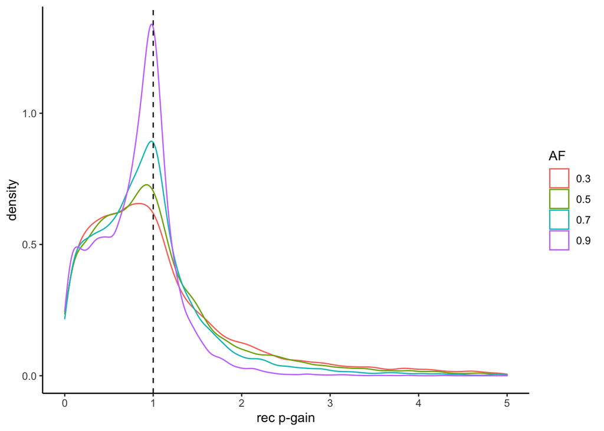

```r
p_gain_density_plot(pgain_type="rec", sim_data=sim_dat, xlim=c(0,5), print_pdf=FALSE)
```

Based on the simulated data, the (1-0.05/#tests)-quantiles of the empirical density of the p-gain are computed by the function `p_gain_quantiles()` where #tests is the number of parallel tests and `n_tests` describes the maximal number of parallel tests:

```r
quantile <- p_gain_quantiles(n_tests=5L, sim_data=sim_dat)
```

For applications with extensive multiple testing the p-gain-quantiles can be interpolated by a log-linear fit by use of the function `p_gain_quantile_fit()` where `test_number` describes the number of parallel tests for which the p-gain threshold should be determined:

```r
list_fits <- p_gain_quantile_fit(pgain_quantile=quantile, test_number=50L, print_pdf=FALSE)
```

```
## [1] "Fitted function for recessive p-gain-quantiles of allele frequency 0.3"
## Nonlinear regression model
##   model: pgain_quantile[[index_rec]][, i] ~ log(a + b * number_tests,     base = d)
##    data: parent.frame()
##      a      b      d
## 1.0632 0.4137 1.0932
##  residual sum-of-squares: 0.01657
##
## Number of iterations to convergence: 11
## Achieved convergence tolerance: 1.49e-08
## [1] "recessive p-gain-threshold for 50 tests, allele frequency 0.3"
##       a
## 34.5696
## [1] "Fitted function for recessive p-gain-quantiles of allele frequency 0.5"
## Nonlinear regression model
##   model: pgain_quantile[[index_rec]][, i] ~ log(a + b * number_tests,     base = d)
##    data: parent.frame()
##      a      b      d
## 1.2146 0.3396 1.1510
##  residual sum-of-squares: 0.01502
##
## Number of iterations to convergence: 11
## Achieved convergence tolerance: 1.49e-08
## [1] "recessive p-gain-threshold for 50 tests, allele frequency 0.5"
##        a
## 20.63311
## [1] "Fitted function for recessive p-gain-quantiles of allele frequency 0.7"
## Nonlinear regression model
##   model: pgain_quantile[[index_rec]][, i] ~ log(a + b * number_tests,     base = d)
##    data: parent.frame()
##     a     b     d
## 1.903 1.912 1.839
##  residual sum-of-squares: 0.0003239
##
## Number of iterations to convergence: 15
## Achieved convergence tolerance: 1.49e-08
## [1] "recessive p-gain-threshold for 50 tests, allele frequency 0.7"
##        a
## 7.519768
## [1] "Fitted function for recessive p-gain-quantiles of allele frequency 0.9"
## Nonlinear regression model
##   model: pgain_quantile[[index_rec]][, i] ~ log(a + b * number_tests,     base = d)
##    data: parent.frame()
##      a      b      d
##  7.959 11.398  7.306
##  residual sum-of-squares: 0.0004434
##
## Number of iterations to convergence: 19
## Achieved convergence tolerance: 1.49e-08
## [1] "recessive p-gain-threshold for 50 tests, allele frequency 0.9"
##        a
## 3.197751
```

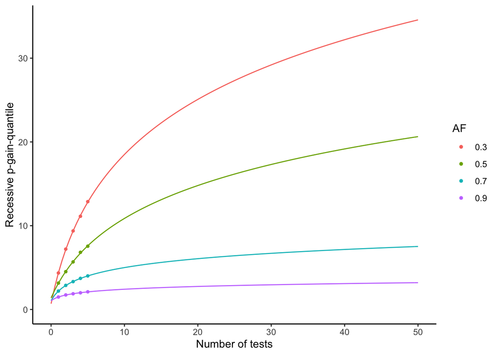

```
## [1] "Fitted function for additive p-gain-quantiles of allele frequency 0.3"
## Nonlinear regression model
##   model: pgain_quantile[[index_add]][, j] ~ log(a + b * number_tests,     base = d)
##    data: parent.frame()
##     a     b     d
## 4.834 2.982 4.740
##  residual sum-of-squares: 0.0002806
##
## Number of iterations to convergence: 14
## Achieved convergence tolerance: 1.49e-08
## [1] "additive p-gain-threshold for 50 tests, allele frequency 0.3"
##        a
## 3.236613
## [1] "Fitted function for additive p-gain-quantiles of allele frequency 0.5"
## Nonlinear regression model
##   model: pgain_quantile[[index_add]][, j] ~ log(a + b * number_tests,     base = d)
##    data: parent.frame()
##     a     b     d
## 3.549 3.259 4.145
##  residual sum-of-squares: 0.0003074
##
## Number of iterations to convergence: 11
## Achieved convergence tolerance: 1.49e-08
## [1] "additive p-gain-threshold for 50 tests, allele frequency 0.5"
##        a
## 3.597121
## [1] "Fitted function for additive p-gain-quantiles of allele frequency 0.9"
## Nonlinear regression model
##   model: pgain_quantile[[index_add]][, j] ~ log(a + b * number_tests,     base = d)
##    data: parent.frame()
##     a     b     d
## 25.31 30.14 25.05
##  residual sum-of-squares: 1.043e-05
##
## Number of iterations to convergence: 34
## Achieved convergence tolerance: 1.49e-08
## [1] "additive p-gain-threshold for 50 tests, allele frequency 0.9"
##        a
## 2.277204
```

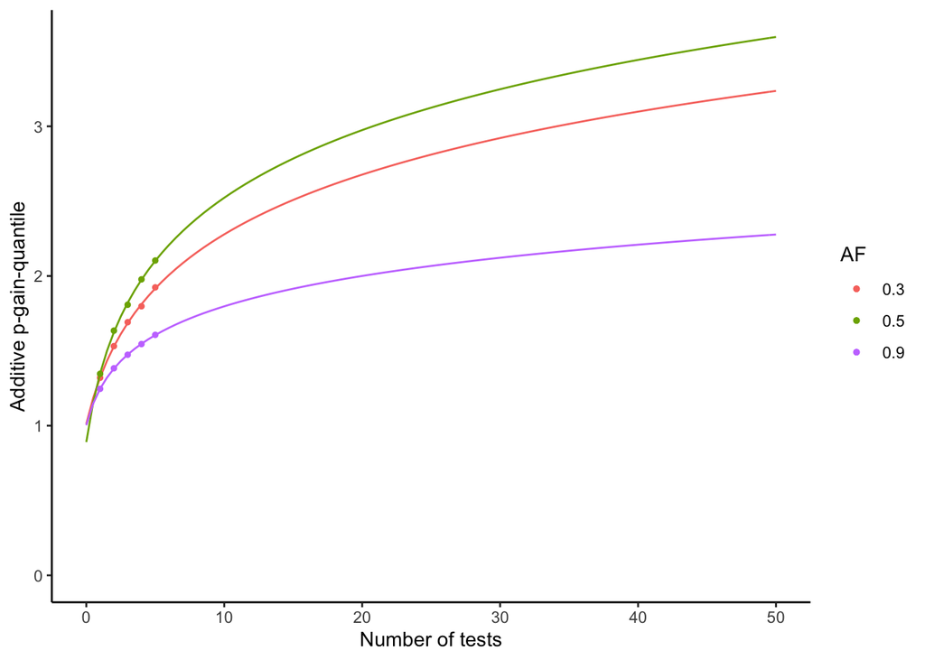

By means of `start_vec` the starting estimates for the log-linear-fit for different p-gain types and allele frequencies can be changed.

For details on the options of all functions please see `?pgainsim` and the corresponding application note by Scherer et al. 2021 (under review).

```r
warnings()
```